# Optimaze Costs of Telecom Clients

Alexander Feldman V.1.0

This project explores the optimal cost for clients of the virtual telephony service CallMeMaybe.  
**The goals of the project:**

- Increase customer loyalty by optimizing their tariff plans.
- Maintaining the current revenue of the service.
1. Preprocessing stage.
2. Exploratory data analysis (EDA) stage.
3. Analysis of revenue.
4. Test hypothesis about optimized revenue.
5. Client churn risk analysis.
6. Conclusions and recommendations.
7. Links.
8. Sources.

## 1. Preprocessing stage.

```python
#!pip install plotly --upgrade
#!pip install seaborn --upgrade
#!pip install pandas_profiling
```

```python
# import libraries
import pandas as pd
import numpy as np
import math as mt
from scipy import stats as st
from matplotlib import pyplot as plt
import seaborn as sns
from pandas_profiling import ProfileReport
from calendar import monthrange
import plotly.express as px
from plotly import graph_objects as go
from plotly.subplots import make_subplots
import datetime as dt
from datetime import datetime
```

```python
# open the dataset
data = pd.read_csv('datasets/telecom_dataset_us.csv') # path for local working
clients = pd.read_csv('datasets/telecom_clients_us.csv')
```

```python
# convert data type
data['date'] = data['date'].astype('datetime64[D]')

# study dataset with pandas_profiling
data_profile = ProfileReport(data, title='Data Report', explorative=True)
```

```python
#data_profile
```

```python
# study the data
data.head()
```

|  | user_id | date | direction | internal | operator_id | is_missed_call | calls_count | call_duration | total_call_duration |
| --- | --- | --- | --- | --- | --- | --- | --- | --- | --- |
| 0 | 166377 | 2019-08-03 | in | False | NaN | True | 2 | 0 | 4 |
| 1 | 166377 | 2019-08-04 | out | True | 880022.0 | True | 3 | 0 | 5 |
| 2 | 166377 | 2019-08-04 | out | True | 880020.0 | True | 1 | 0 | 1 |
| 3 | 166377 | 2019-08-04 | out | True | 880020.0 | False | 1 | 10 | 18 |
| 4 | 166377 | 2019-08-04 | out | False | 880022.0 | True | 3 | 0 | 25 |

```python
display(data.info(),data.describe())
```

```
<class 'pandas.core.frame.DataFrame'>
RangeIndex: 53902 entries, 0 to 53901
Data columns (total 9 columns):
 #   Column               Non-Null Count  Dtype
---  ------               --------------  -----
 0   user_id              53902 non-null  int64
 1   date                 53902 non-null  datetime64[ns]
 2   direction            53902 non-null  object
 3   internal             53785 non-null  object
 4   operator_id          45730 non-null  float64
 5   is_missed_call       53902 non-null  bool
 6   calls_count          53902 non-null  int64
 7   call_duration        53902 non-null  int64
 8   total_call_duration  53902 non-null  int64
dtypes: bool(1), datetime64[ns](1), float64(1), int64(4), object(2)
memory usage: 3.3+ MB
```

```
None
```

|  | user_id | operator_id | calls_count | call_duration | total_call_duration |
| --- | --- | --- | --- | --- | --- |
| count | 53902.000000 | 45730.000000 | 53902.000000 | 53902.000000 | 53902.000000 |
| mean | 167295.344477 | 916535.993002 | 16.451245 | 866.684427 | 1157.133297 |
| std | 598.883775 | 21254.123136 | 62.917170 | 3731.791202 | 4403.468763 |
| min | 166377.000000 | 879896.000000 | 1.000000 | 0.000000 | 0.000000 |
| 25% | 166782.000000 | 900788.000000 | 1.000000 | 0.000000 | 47.000000 |
| 50% | 167162.000000 | 913938.000000 | 4.000000 | 38.000000 | 210.000000 |
| 75% | 167819.000000 | 937708.000000 | 12.000000 | 572.000000 | 902.000000 |
| max | 168606.000000 | 973286.000000 | 4817.000000 | 144395.000000 | 166155.000000 |

We have in the data: 53902 rows, 4900 duplicate rows (9,1\% of all), 117 missing values (0,2%) for the 'internal' column, 8172 missing values (15,2\%) for the 'operator_id' column. we have a time series from 2019-08-01 to 2019-11-27 in the date column.

The dataset is a pivot table grouped by user_id, date, direction, internal, operator_id, is_missed_call, calls_count columns. in this case, duplicated rows are no problem.

```python
# Fill in the missing values for the "internal" columns as internal calls. Let's choose the worst option for us.
data['internal'] = data['internal'].fillna(True)
```

```python
# study clients dataset
display(clients.info(),clients.head())
```

```
<class 'pandas.core.frame.DataFrame'>
RangeIndex: 732 entries, 0 to 731
Data columns (total 3 columns):
 #   Column       Non-Null Count  Dtype
---  ------       --------------  -----
 0   user_id      732 non-null    int64
 1   tariff_plan  732 non-null    object
 2   date_start   732 non-null    object
dtypes: int64(1), object(2)
memory usage: 17.3+ KB
```

```
None
```

|  | user_id | tariff_plan | date_start |
| --- | --- | --- | --- |
| 0 | 166713 | A | 2019-08-15 |
| 1 | 166901 | A | 2019-08-23 |
| 2 | 168527 | A | 2019-10-29 |
| 3 | 167097 | A | 2019-09-01 |
| 4 | 168193 | A | 2019-10-16 |

```python
print('Whether duplicate rows in the clients?', clients.duplicated().any())
```

```
Whether duplicate rows in the clients? False
```

We have 732 clients. No missing values, no duplicate rows.

```python
# convert to date type
clients['date_start'] = clients['date_start'].astype('datetime64[D]')
```

```python
# convert some data to suitable format
data['month'] = data['date'].astype('datetime64[M]')
data['is_missed_call'] = data['is_missed_call'].astype(int)
data['internal'] = data['internal'].astype(int)
data['direction'] = data['direction'].apply(lambda x: 1 if x=='out' else 0)
```

```python
# Study why there are missing values in operator_id
n_na_operator_id=len(data[data['operator_id'].isna()])
n_na_operator_miss_calls = len(data[(data['operator_id'].isna()) & (data['is_missed_call']==1)\
                                    & (data['call_duration']==0)])
print('We have', n_na_operator_id, 'missing values for the operator_id column.')
print(n_na_operator_miss_calls, 'from ones ({:.1%}) are missed calls with 0-calls duration.'\
      .format(n_na_operator_miss_calls/n_na_operator_id))
```

```
We have 8172 missing values for the operator_id column.
8050 from ones (98.5%) are missed calls with 0-calls duration.
```

In those cases, operators were not involved.  
But in some cases, it seems that something has worked wrong.  
For example:

```python
data[(data['operator_id'].isna()) & (data['is_missed_call']==0) & (data['call_duration']!=0)]\
.sort_values('call_duration', ascending=False).head()
```

|  | user_id | date | direction | internal | operator_id | is_missed_call | calls_count | call_duration | total_call_duration | month |
| --- | --- | --- | --- | --- | --- | --- | --- | --- | --- | --- |
| 50764 | 168252 | 2019-11-21 | 0 | 0 | NaN | 0 | 52 | 26175 | 26347 | 2019-11-01 |
| 50746 | 168252 | 2019-11-21 | 0 | 0 | NaN | 0 | 52 | 26175 | 26347 | 2019-11-01 |
| 50946 | 168252 | 2019-11-27 | 0 | 0 | NaN | 0 | 45 | 23765 | 23897 | 2019-11-01 |
| 50898 | 168252 | 2019-11-26 | 0 | 0 | NaN | 0 | 52 | 23706 | 23894 | 2019-11-01 |
| 50813 | 168252 | 2019-11-24 | 0 | 0 | NaN | 0 | 49 | 23658 | 23854 | 2019-11-01 |

There are a lot of unmissed calls with the same durations and no operators. This seems to be a technical problem.  
We will leave this as it is and report this issue to the development team.

## 2. Exploratory data analysis (EDA)

```python
# make some columns for analysis call metrics.
data['out_call_duration'] = data.apply(lambda x: x[8] if x[2]==1 and x[3]==0 else 0, axis=1)
data['out_int_call_duration'] = data.apply(lambda x: x[8] if x[2]==1 and x[3]==1 else 0, axis=1)
data['n_missing_calls'] = data['is_missed_call']*data['calls_count']
data['n_missing_out_calls'] = data['n_missing_calls']*data['direction']
data['n_internal_calls'] = data['internal']*data['calls_count']
data['n_out_calls'] = data['direction']*data['calls_count']
```

```python
# Found out the number of operators per client
n_operators_per_client = data.groupby('user_id', as_index=False).agg({'operator_id':'nunique'})
n_operators_per_client.columns=['user_id','n_operators']
print('Clients have from', n_operators_per_client['n_operators'].min(), "to",
      n_operators_per_client['n_operators'].max(),'operators')
```

```
Clients have from 0 to 50 operators
```

```python
# study clients whithout operators
no_operators_clients = data[data['user_id'].isin(n_operators_per_client[n_operators_per_client['n_operators']==0]\
                                                ['user_id'])]['user_id'].unique()
```

```python
print(len(no_operators_clients),'small clients do not have any operators')
```

```
17 small clients do not have any operators
```

Perhaps those clients use the service as informing of clients by an answering machine.

```python
# Study some call metrics.
calls_month = data.groupby('month', as_index=False).agg({'calls_count':'sum','total_call_duration':'sum',
                                                        'user_id':'nunique', 'n_missing_calls':'sum',
                                                          'out_call_duration':'sum',
                                                        'n_internal_calls':'sum', 'n_out_calls':'sum'})
calls_month['month']=calls_month['month'].apply(lambda x: x.strftime('%b %Y'))
calls_month.columns=['Months', 'Number of calls', 'Total call durations, sec', 'Number of clients',
                     'Number of missing calls', 'Out-call duration',
                     'Number of internal calls', 'Number of out-calls']
calls_month['Number of in-calls'] = calls_month['Number of calls'] - calls_month['Number of out-calls']
calls_month['Average out-call duration, sec'] = calls_month['Out-call duration'] / (calls_month['Number of out-calls']-
                                                                               calls_month['Number of missing calls'])
```

```python
# Plot a bar charts for call metrics
fig = make_subplots(rows=3, cols=3, subplot_titles=calls_month.columns[1:])
colors=px.colors.qualitative.Set1
col=1
row=1
for label in calls_month.columns[1:]:
    fig.add_trace(go.Bar(x=calls_month['Months'], y=calls_month[label], text=calls_month[label],
                         marker={'color':colors}), row, col)
    if col<3:
        col+=1
    elif col==3:
        col=1
        row+=1
fig.update_layout(title={'text':'Call metrics'},
                  height=800, bargap=0.1, barmode='group', showlegend=False)
fig.update_traces(texttemplate='%{text:.2s}', textposition='auto')
fig.show()
```

[interactive chart not shown]

```python
# Plot a bar charts for call metrics
fig = make_subplots(rows=1, cols=3, specs=[[{'type':'domain'}, {'type':'domain'}, {'type':'domain'}]],
                    subplot_titles=('Share of missing/unmissing calls',
                                                    'Share of int/ext calls',
                                                   'Share of in/out calls'))
fig.add_trace(go.Pie(labels=['Missing calls', 'Unmissing calls'], values=[calls_month['Number of missing calls'].sum(),
                                calls_month['Number of calls'].sum()-calls_month['Number of missing calls'].sum()],
                    marker=dict(colors=px.colors.qualitative.Set1, line=dict(color='#FFFFFF', width=1))),1, 1)
fig.add_trace(go.Pie(labels=['Internal calls', 'External calls'], values=[calls_month['Number of internal calls'].sum(),
                                calls_month['Number of calls'].sum()-calls_month['Number of internal calls'].sum()],
                    marker=dict(colors=px.colors.qualitative.Set1[1:], line=dict(color='#FFFFFF', width=1))),1, 2)
fig.add_trace(go.Pie(labels=['In-calls', 'Out-calls'], values=[calls_month['Number of in-calls'].sum(),
                                calls_month['Number of out-calls'].sum()],
                    marker=dict(colors=px.colors.qualitative.Set1[2:], line=dict(color='#FFFFFF', width=1))),1, 3)
fig.update_layout(title={'text':'Share of calls'},showlegend=False)
fig.update_traces(textinfo='label+percent', textfont_size=12
                  )
fig.show()
```

[interactive chart not shown]

As you can see from the bar charts, all metrics were growing until November. However, after November, the number of clients decreased. As a result, the number of calls was also reduced. But internal calls and incoming calls have increased. As you can see from the pie charts, there is a huge number of missed calls (46.5%). This fact can become a growth point. Less than 2% of all went to internal calls. 75% of calls are outgoing.

## 3. Analysis of revenue

```python
# Make the function which calculate a revenue per client by month.
def calc_revenue(client_table, active_users):
    '''
    The function calculates revenue per client with accounting tariffs, calls,
    number of operators, the number of days on the service in a month.
    The function accepts the client table and a flag 'active_users' (True, False),
    which defines whether include in calculating clients who have used the service
    after 1 Nov 2019 or not.
    '''
    # set prices
    tariff = [5000, 2000, 1000]
    price_int_per_sec=[0.1/60, 0.15/60, 0.3/60]
    limit_free_int_call = 2000 * 60  # in seconds
    price_per_sec=[0.4/60, 0.5/60, 0.7/60]
    pay_each_operator = 100

    # calculate revenue
    pays = data.groupby(['user_id','month'],as_index=False).agg({'out_call_duration':'sum',
                                                                     'out_int_call_duration':'sum'})
    pays=pays.join(client_table.set_index('user_id'), on='user_id')
    pays['date_start']=pays['date_start'].astype('datetime64[D]')
    pays['price_per_sec'] = pays.apply(lambda x: price_per_sec[0] if x[4]=='A'
                                          else (price_per_sec[1] if x[4]=='B' else price_per_sec[2]), axis=1)
    pays['price_int_per_sec'] = pays.apply(lambda x: price_int_per_sec[0] if x[4]=='A'
                                           else (price_int_per_sec[1] if x[4]=='B' else price_int_per_sec[2]), axis=1)
    pays['days_in_current_month'] = monthrange(pays['month'].dt.year.any(), pays['month'].dt.month.any())[1]
    pays['days_use_service'] = np.where(pays['date_start'].dt.month == pays['month'].dt.month,
                                        pays['days_in_current_month'] - pays['date_start'].dt.day +1,
                                        pays['days_in_current_month'])
    pays['out_int_call_dur_on_limit'] = pays.apply(lambda x: 0 if x[3]<limit_free_int_call
                                                       else x[3]-limit_free_int_call, axis=1)
    pays['day_tariff'] = pays.apply(lambda x: tariff[0]/x[8] if x[4]=='A' else (tariff[1]/x[8] if x[4]=='B' else
                                                                                   tariff[2]/x[8]), axis=1)
    pays = pays.join(n_operators_per_client.set_index('user_id'), on='user_id')

    pays['revenue'] = pays.apply(lambda x: x[2]*x[6]+x[10]*x[7]+x[9]*x[11]+pay_each_operator*x[12] , axis=1)
    # Filtering only active clients who have used the services after 01.11.2019.
    if active_users==True:
        active_clients = pays.query('month == "2019-11-01"').user_id.unique()
        pays = pays[pays['user_id'].isin(active_clients)]
    return pays
```

```python
payments = calc_revenue(clients, active_users=True)
clients_pays = payments.groupby('user_id', as_index=False)['revenue'].mean()
x_values = pd.Series(range(0, len(clients_pays)))
fig = px.scatter(clients_pays, x=x_values, y='revenue', title='Average month revenue by clients',
                labels={'x':'Count of clients', 'revenue':'Average month revenue'},
                color_discrete_sequence=px.colors.qualitative.Set1)
fig.show()
```

[interactive chart not shown]

As we can see from the scatter plot the largest part of clients has an average monthly revenue of less than 5000. Some clients with revenue from 5000 to 12000 and only 2 big clients with revenue more than 25 000.

```python
payments_tariff = payments.groupby('tariff_plan', as_index=False).agg({'revenue':'sum', 'user_id':'nunique'})
payments_tariff = payments_tariff.rename(columns={'user_id':'n_users'})
payments_tariff['revenue'] = payments_tariff['revenue'].round(0)
```

```python
fig = make_subplots(rows=1, cols=2, specs=[[{'type':'domain'}, {'type':'domain'}]])
fig.add_trace(go.Pie(labels=payments_tariff['tariff_plan'], values=payments_tariff['revenue'],
                     name="Revenue"), 1, 1)
fig.add_trace(go.Pie(labels=payments_tariff['tariff_plan'], values=payments_tariff['n_users'],
                     name="Number of clients"), 1, 2)

fig.update_traces(hole=.4, textinfo='value + percent', hoverinfo="label+value+name",
                 marker=dict(line=dict(color='#FFFFFF', width=2),colors=px.colors.qualitative.Set1))
fig.update_layout(
    title_text="Revenue and number of clients by tariff plans",
    annotations=[dict(text='Revenue', x=0.19, y=0.5, font_size=12, showarrow=False, font_color='Blue'),
                 dict(text='Number of clients', x=0.87, y=0.5, font_size=12, showarrow=False,font_color='Blue')])
fig.show()
```

[interactive chart not shown]

Revenues from different tariff plans are divided almost equally. This is about a third for each tariff. But the number of clients of C tariff is more than 50% and the number of clients of A tariff 12% only. 37% is of B tariff.

```python
# Let's study a churning of clients.
payments_churn = calc_revenue(clients, active_users=False)
payments_churn['churn'] = np.where(payments_churn['user_id']==payments_churn['user_id'].shift(periods=-1), 0, 1)
payments_churn['inflow'] = np.where(payments_churn['user_id']==payments_churn['user_id'].shift(), 0, 1)
```

```python
#Lets study churn rate by cohort
payments_churn['cohort']=payments_churn['date_start'].dt.month
payments_churn['cohort']=payments_churn['cohort'].apply(lambda x: 0 if x==8 else (1 if x==9 else (2 if x==10 else 3)))

churn_cohort = payments_churn.groupby(['month', 'cohort'],as_index=False).agg({'user_id':'nunique','churn':'sum'})
churn_cohort=churn_cohort.rename(columns={'user_id':'n_users','churn':'n_churn_users'})
churn_cohort['churn_rate']=churn_cohort['n_churn_users']/churn_cohort['n_users']
churn_rate=churn_cohort.pivot_table(index='cohort',columns='month',values='churn_rate')
churn_rate.columns=['Sep 2019', 'Oct 2019', 'Nov 2019', 'del']
churn_rate=churn_rate.drop('del',axis=1)
```

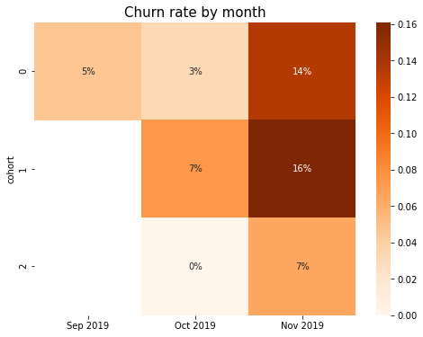

```python
plt.figure(figsize=(8,6))
ax = sns.heatmap(churn_rate, cmap="Oranges", annot=True,
                 xticklabels=['Sep 2019', 'Oct 2019', 'Nov 2019'], fmt=".0%")
plt.title('Churn rate by month', fontdict={'size':15})
plt.show()
```

As we can see we had churn rate up to 16%. This is an alarming call.

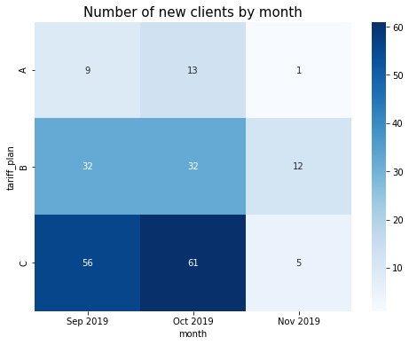

```python
inflow_map = payments_churn.query('month!="2019-08-01"').pivot_table(index='month', columns='tariff_plan',
                                                                    values='inflow', aggfunc='sum')

plt.figure(figsize=(8,6))
ax = sns.heatmap(inflow_map.T, cmap="Blues", annot=True, xticklabels=['Sep 2019', 'Oct 2019', 'Nov 2019'])
plt.title('Number of new clients by month', fontdict={'size':15})
plt.show()
```

As we can see a company has actively attracted new clients. Unfortunately, we don't have the value of costs of this attracting.

## 4. Test hypothesis about optimized revenue

Let's try optimize tariff plans of clients. To do this, we will calculate the revenue from customers by supplying them with other tariff plans. If a new tariff plan is less expensive for the client, then such a tariff plan can be considered optimized.  
Let's check the hypothesis that as a result of the optimization of tariff plans, the average revenue from clients will significantly decrease.

```python
# make table for compaire costs of clients for other tariff plans
compare = payments[['user_id', 'month', 'tariff_plan', 'revenue']]

# make the what-if-clients-datasets for other tariff plans (variants #1 and #2)
clients_1 = clients[['user_id','tariff_plan','date_start']]
clients_1['tariff_plan'] = clients_1['tariff_plan'].apply(lambda x: 'A' if x=='C' else
                                                           ('B' if x=='A' else 'C'))
clients_2 = clients[['user_id','tariff_plan','date_start']]
clients_2['tariff_plan'] = clients_2['tariff_plan'].apply(lambda x: 'B' if x=='C' else
                                                           ('C' if x=='A' else 'A'))
#calculate revenues
payments_1 = calc_revenue(clients_1, active_users=True)
payments_2 = calc_revenue(clients_2, active_users=True)


# compire results
compare = compare.join(payments_1.set_index(['user_id', 'month'])[['tariff_plan', 'revenue']],
                       on=['user_id', 'month'], rsuffix = '_1')
compare = compare.join(payments_2.set_index(['user_id', 'month'])[['tariff_plan', 'revenue']],
                       on=['user_id', 'month'], rsuffix = '_2')
compare['revenue_after_optmz'] = compare.apply(lambda x: x[3] if x[3]<x[5] and x[3]<x[7] else
                                              (x[5] if x[5]<x[7] else x[7]), axis=1)
# calculate optimized tariff plan.
compare['optmzed_tariff_plan'] = compare.apply(lambda x: x[2] if x[8]==x[3] else
                                              (x[4] if x[8]==x[5] else x[6]), axis=1)
# calculate losses after an optimization
compare['losses'] = compare['revenue'] - compare['revenue_after_optmz']
```

**Formulate hypothesis:**

- Null hypothesis: Averege monthly revenue from clients and Averege revenue from clients after optimization of tariff plans the same.
- Alternative hypothesis: Averege monthly revenue from clients and Averege revenue from clients after optimization of tariff plans have a significant difference.

Set alpha level = 0,1

```python
# prepare samples
#drop extra large values of revenue (> 25k per month). It's outliers.

sample_before=compare[compare['revenue']<25000]['revenue']
sample_after=compare[compare['revenue_after_optmz']<25000]['revenue_after_optmz']
# set alpha level
alpha = .1
# make test
results = st.ttest_ind(
        sample_before,
        sample_after)

print('p-value: ', results.pvalue)

print('The difference is: {:.2f} or {:.1%}'.format(sample_after.mean()-sample_before.mean(),
                                                  (sample_after.mean()-sample_before.mean())/sample_before.mean()))
if (results.pvalue < alpha):
        print('We reject the null hypothesis. Average monthly revenue between groups have a significant difference')
else:
        print("We can't reject the null hypothesis. Average monthly revenue between groups are equal")
```

```
p-value:  5.831192027397766e-13
The difference is: -668.32 or -29.2%
We reject the null hypothesis. Average monthly revenue between groups have a significant difference
```

As we can see from the result of the test average monthly revenue after optimization less almost 30% than before.  
Lets study our losses more details.

## 5. Client churn risk analysis

```python
# group data for plotting
compare_gr = compare.groupby('month', as_index=False).agg({'revenue':'sum', 'revenue_after_optmz':'sum', 'losses':'sum'})
compare_gr['month']=compare_gr['month'].apply(lambda x: x.strftime('%b %Y'))
compare_gr['losses_prc']=compare_gr.apply(lambda x: x[3]/x[1],axis=1)
compare_gr[['revenue','revenue_after_optmz','losses']]=compare_gr[['revenue','revenue_after_optmz','losses']].round(0)
```

```python
# Plot the compare of revenue and revenue after optimizing of tariff plans.
fig = go.Figure(data=[
    go.Bar(name='revenue', x=compare_gr['month'], y=compare_gr['revenue'], text=compare_gr['revenue'],
          marker=dict(color=px.colors.qualitative.Set1[4])),
    go.Bar(name='optimized revenue', x=compare_gr['month'], y=compare_gr['revenue_after_optmz'],
          text=compare_gr['revenue_after_optmz'], marker=dict(color=px.colors.qualitative.Set1[1]))])
fig.update_layout(title_text="Compare between revenue and revenue after optimizing of tariff plans by month",
                  barmode='group')
for row in compare_gr.itertuples():
    element = 'Losses: -'+str(round(row.losses_prc*100,1))+'%'
    fig.add_annotation(x=row.Index, y=row.revenue+20000, text=element,  showarrow=False,
                       font_size=12, font_color='grey')
fig.update_traces(texttemplate='%{text:.2s}', textposition='auto')
fig.show()
```

[interactive chart not shown]

Let's try to determine which clients are at risk of leaving. Let's assume that:

- The opportunity to reduce costs by less than 5% will not lead to a change of provider, that is, this is a low risk area.
- The opportunity to reduce costs from 5 to 20% may or may not lead to a change of provider. That is, this is an area of medium risk.
- The opportunity to reduce costs by more than 20% will definitely entail a change of provider. This is a high risk area.

```python
clients_risk = compare.groupby('user_id', as_index=False).agg({'revenue':'mean','revenue_after_optmz':'mean',
                                                                  'losses':'mean'}).round(0)
clients_risk['churn_risk_zone'] = clients_risk.apply(lambda x: 'High' if x['losses']/x['revenue']>=0.2
                                                        else ('Low' if x['losses']/x['revenue']<=0.05
                                                              else 'Medium'), axis=1)
```

```python
fig = px.scatter(clients_risk, x='revenue_after_optmz', y='losses', color='churn_risk_zone',
                 title='Average losses and average new revenue by clients',
                labels={'revenue_after_optmz':'Average new month revenue', 'losses':'Average month losses'},
                category_orders={'churn_risk_zone':['High','Medium','Low']}, trendline="lowess",
                color_discrete_sequence=px.colors.qualitative.Set1)
fig.update_layout(legend_title_text='Churn risk zones')
fig.show()
```

[interactive chart not shown]

As we can see from the scatter plot the largest part of clients are in the high churn risk zone.  
It means that churning will be continuing and grow because in the end the clients will come to understanding the reducing of their costs and will looking for other options on the market. The cost of attracting new customers will be wasted.

# 6. Conclusions and recommendations

**The general conclusion:** We should optimize all tariff plans for all clients automatically. No matter what now it brings losses, but it let us increase the client’s loyalty, reduce a churn rate, and accelerate the speed of growth.

**Recommendations for keeping revenue:**

To increase revenue, we need to increase one of the following call metrics: the number of outgoing calls, the average duration of outgoing calls. And also to reduce the number of missed outgoing calls. We see that 46.5% of calls are missed calls. If we manage to reduce this indicator (especially outgoing calls, but also incoming calls, because the quality of customer service will lead to an overall increase in outgoing traffic), then we will get an increase in paid traffic.

- Offer customers additional call processing services: a smart voice robot for handling both incoming and outgoing calls.
- Organize your own call center and offer clients to process incoming calls at the price of outgoing calls.
- Offer customers operator training courses. In addition to income from the courses themselves, this will lead to an increase in the level of customer service of client companies, and can also increase the duration of outgoing calls.

Applying all or several of the revenue keeping methods will accelerate revenue recovery by up to 1-2 months. It will also provide new business opportunities.

## 7. Links

- [Link to presentation](https://www.dropbox.com/s/yqf3241l6bgldm1/Alex_Feldman_Telecom_v.1.0.pdf?dl=0)
- [Link to Dashboard](https://public.tableau.com/views/Telecom_16096971134910/Callsdistribution?:language=en&:display_count=y&publish=yes&:origin=viz_share_link)

## 8. Sources

1. https://docs.python.org/3.7/library/calendar.html
2. https://pandas-profiling.github.io/pandas-profiling/docs/master/rtd/pages/getting_started.html
3. https://medium.com/python-in-plain-english/statistical-tests-with-python-880251e9b572